# Stopping Distances of Cars – Simple Linear Regression

#### Background

Data was collected on the speed and stopping distances of cars during the 1920’s. It seems reasonable to assume that the faster a car was going, the longer it would take to stop. Data was collected both to see if this was true or not, and to estimate the effect of speed on the stopping distance.

#### Analysis

The scatterplot below demonstates the observed relationship between speed and stopping distance.

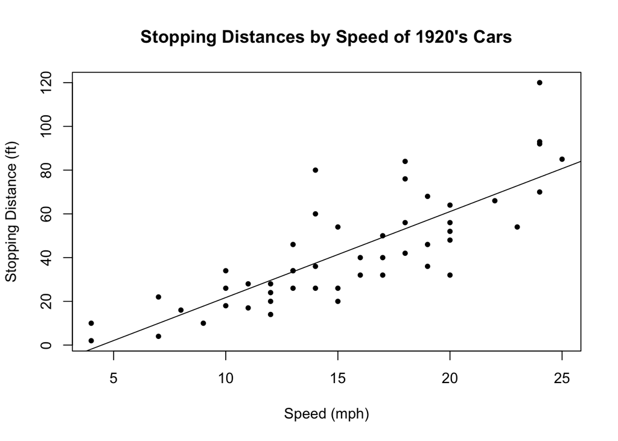

There does appear to be some evidence of a relationship. Assuming the relationship is linear, the equation of the fitted line shown in the plot above is

Y = -17.58 + 3.93 X

A test of the hypotheses that $H_0: \beta_1 = 0$ $H_a: \beta_1 \neq 0$

shows that the slope is significant $(p < 0.0001)$. Hence the relationship is **meaningful**.

#### Interpretation

If the model is appropriate, then we estimate that increasing the speed by 1 mph will result in an extra 3.93 feet of stopping distance (95% CI: (3.1, 4.77) feet). As a general rule of thumb we suggest “4 extra feet of stopping distance for every 1 mph increase in speed.” Note that the baseline of 0 mph actually has a negative stopping distance. Thus we restrict the interpretability of the model to speeds of 5 or more mph. At a speed of 5 mph or less, the stopping distance is essentially zero. (Although, we do note that one vehicle took 10 feet to stop at a speed of 4 mph. Bad driver perhaps? At a minimum the vehicle needs new brakes.)

A check on the **appropriateness** of the model shows some question about whether the relation should be assumed to be linear or not. The residuals do not depart too dramatically from normality. Efforts were made in an attempt to correct the potential difficulty with linearity (see the Transformations section below). However, the above model and interpretation was determined to be the most appropriate, although still questionable, for these data.

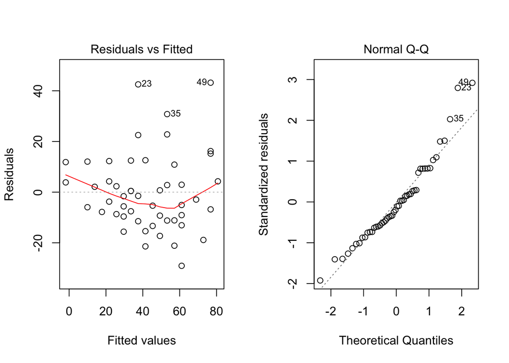

#### Transformations

A few transformations on the data show possible approaches to fixing the potential non-linear difficulty. Taking the square root of speed or the log of speed appears to worsen the non-linear difficulties. However, squaring the speed seems to improve the linear relationship, although there is now some question about the constant variance.

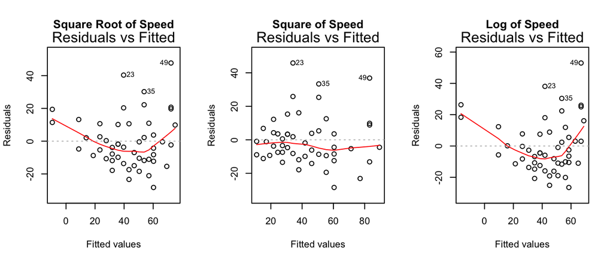

Although some interpretability is lost by squaring the speed, the linear relation is improved.

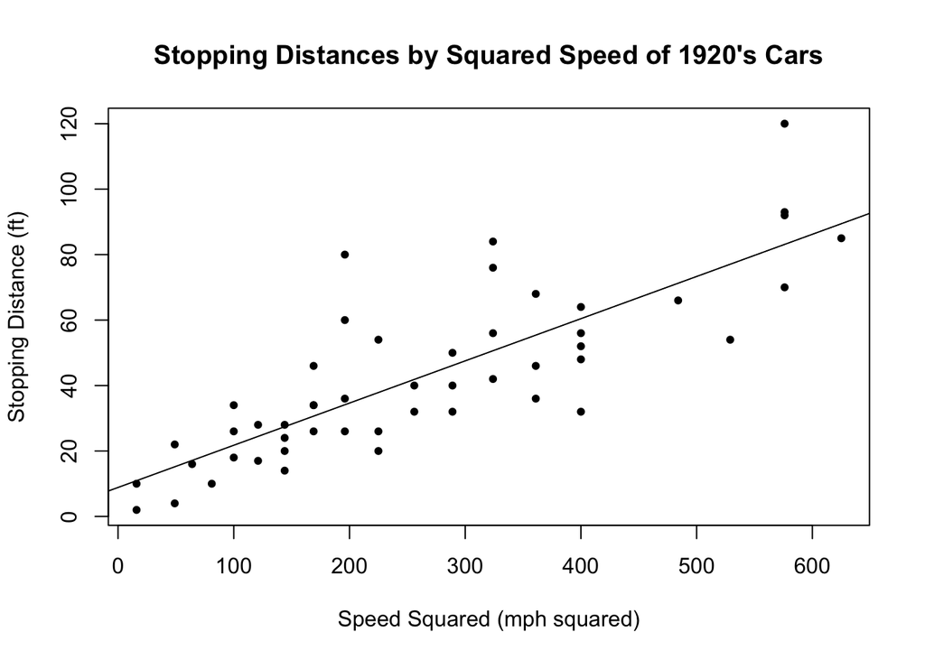

Unfortunately, the constant variance and normality of the errors now both appear more questionable than before. Due to these reasons, the original regression will be the one presented as the most appropriate and interpretable for these data.

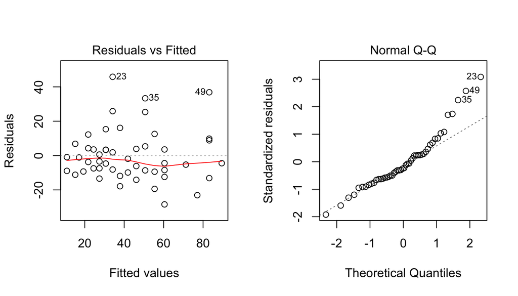